# Problem set 5 key: Consumer-resource

```r
library(package = "deSolve")
library(package = "viridis")
library(package = "phaseR")
```

## 1. Lotka-Volterra isoclines and trajectory, part uno

We started consumer-resource/predator-prey interactions last week. Vandermeer and Goldberg (2012) open the chapter with the Lotka-Volterra predator-prey system of equations:
$$\begin{aligned}
\frac{\mathrm{d}V}{\mathrm{d}t} &= rV - aVP \\
\frac{\mathrm{d}P}{\mathrm{d}t} &= bVP - mP.
\end{aligned}$$
This system describes density-independent prey, $V$ (for “victim” since predator and prey both begin with “p”), growth at rate $r$ and density-independent predator, $P$, death, $-m$. It further describes the constant rate at which prey are being attacked/eaten/dying, $a$, and the rate at which the predator population is growing by eating prey and converting that into population growth, $b$.

1.1. For last week’s quiz you found the equilibrium for each of these two equations. Please, on a blank plot, plot the two for the prey and the two from the predator populations on a single graph. A useful way to plot a line is to make an $x$ vector with the first and last $x$ values and plot that against a vector with the first and last values; e.g.,

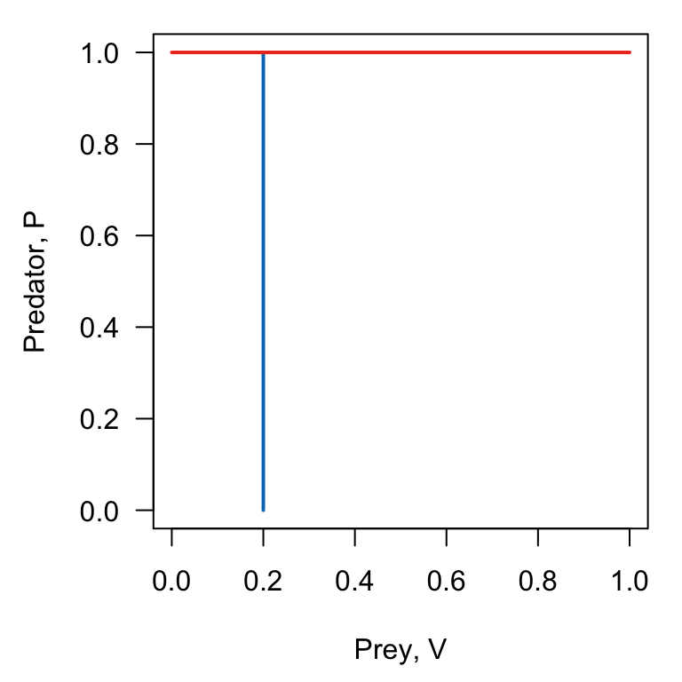

```r
par(mar = c(4.5, 4.5, 1, 1))

# Blank plot with horizontal, x, and vertical, y, axes from 0 to 1
plot(x = NA, type = "n", las = 1, xlab = "Prey, V", ylab = "Predator, P", xlim = c(0, 1), ylim = c(0, 1))

# Just some lines
x_vec1 <- c(0.2, 0.2)
y_vec1 <- c(0, 1)
lines(x = x_vec1, y = y_vec1, col = "#007ac1", lwd = 2)

x_vec2 <- c(0, 1)
y_vec2 <- c(1, 1)
lines(x = x_vec2, y = y_vec2, col = "#ef3b24", lwd = 2)
```

This week we will discuss these lines where the rates of change are 0. But note that these are called nullclines or zero-growth isoclines that your book abbreviates as *isoclines*. Both terms are synonymous.

1.2. Isoclines, like equilibria, denote breaks where there is a change in the direction of growth. Remembering back to the equilibria of the logistic equation when we plotted $dN/dt$ against $N$, at each equilibrium, there was a change in the direction of growth (irrespective of stability). Draw it out on scratch paper to see what I mean. At the unstable equilibrium at $N^* = 0$, **the population decreases to the left** of that equilibrium and **increases to the right** of that equilibrium. At the stable equilibrium at $N^* = K$, the population **increases to the left** and **decreases to the right** of that equilibrium.

For these predator-prey isoclines, it’s no different. For each population—in this case the predator or prey—**their direction of growth will change on each side of their own isocline**. Let’s see this with an example. For this question, I would like for you to:

A. First, numerically integrate the Lotka-Volterra predator-prey model using arbitrary initial densities, parameter values, and length of time.  
B. Second, create a blank plot like 1.1., but make sure that your axis limits will show the isoclines.  
C. Plot the isoclines in the same way that you did for 1.1., but make sure that they correspond to the parameter values that you used in A.  
D. Plot a point with your initial densities using `points()`.  
E. Using `lines()`, plot the trajectory of the system, which is how the predator and prey populations change over time. These are, effectively, the solution from your numerical integration in A.  
F. You may need to adjust your `xlim` and `ylim` from your initial plot in A to make sure that you show the trajectory of your populations.

1.3. From 1.2., plot a time series with both populations on the same graph.

1.4. Lastly, interpret the figure you made in 1.2. I just want to make sure what you did makes sense and makes sense to you.

> 1.1

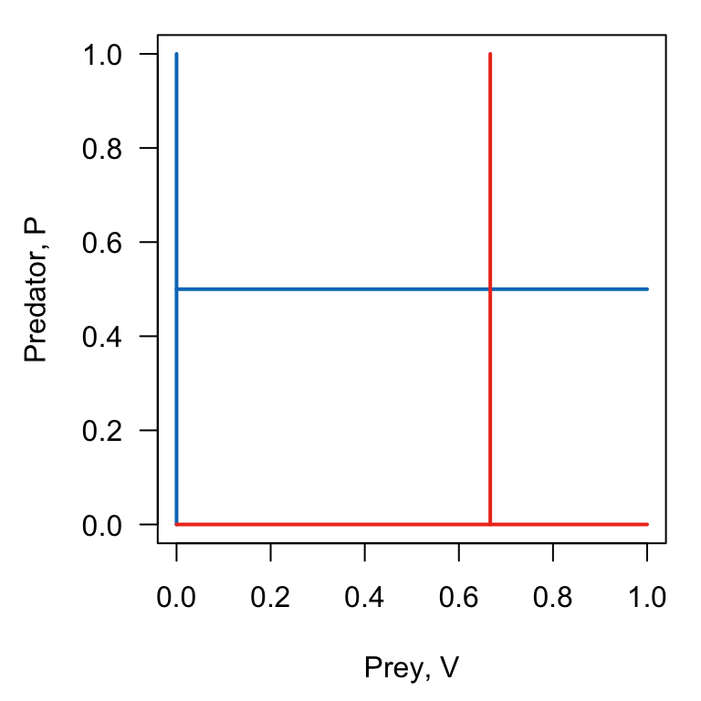

> ```r
> # Arbitrarily-chosen parameter values
> par_vec <- c(r = 0.25, a = 0.5, b = 0.3, m = 0.2)
>
> # Blank plot with horizontal, x, and vertical, y, axes from 0 to 1
>   par(mar = c(4.5, 4.5, 1, 1))
>   plot(x = NA, type = "n", las = 1, xlab = "Prey, V", ylab = "Predator, P", xlim = c(0, 1), ylim = c(0, 1))
>
>
> # Prey isoclines
>   # Isoclines for prey
>   lines(x = c(0, 0), y = c(0,1), col = "#007ac1", lwd = 2)
>   iso_V <- par_vec["r"]/par_vec["a"]
>   lines(x = c(0, 1), y = c(iso_V, iso_V), col = "#007ac1", lwd = 2)
>
>   # Isoclines for predators
>   lines(y = c(0, 0), x = c(0,1), col = "#ef3b24", lwd = 2)
>   iso_P <- par_vec["m"]/par_vec["b"]
>   lines(y = c(0, 1), x = c(iso_P, iso_P), col = "#ef3b24", lwd = 2)
> ```

> 1.2

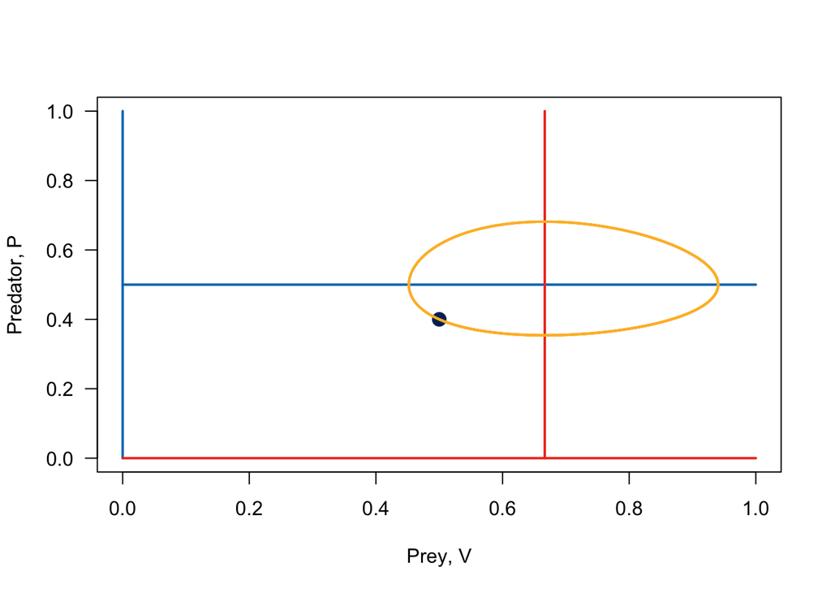

> ```r
> # ode() set up
> lv <- function(times, state, pars) {
>   with(as.list(c(state, pars)), {
>     dV <- r*V - a*V*P
>     dP <- b*V*P - m*P
>     return(list(c(dV, dP)))
>   })
> }
>
> time_vec <- seq(from = 0, to = 100, by = 0.1)
> par_vec <- c(r = 0.25, a = 0.5, b = 0.3, m = 0.2)
> init <- c(V = 0.5, P = 0.4)
>
> # Numerical solution
>   out <- ode(y = init, times = time_vec, func = lv, parms = par_vec)
>
> # Plot
>   # Blank plot
>   plot(x = NA, type = "n", las = 1, xlab = "Prey, V", ylab = "Predator, P", xlim = c(0, 1), ylim = c(0, 1))
>
>   # Isoclines for prey
>   lines(x = c(0, 0), y = c(0,1), col = "#007ac1", lwd = 2)
>   iso_V <- par_vec["r"]/par_vec["a"]
>   lines(x = c(0, 1), y = c(iso_V, iso_V), col = "#007ac1", lwd = 2)
>
>   # Isoclines for predators
>   lines(y = c(0, 0), x = c(0,1), col = "#ef3b24", lwd = 2)
>   iso_P <- par_vec["m"]/par_vec["b"]
>   lines(y = c(0, 1), x = c(iso_P, iso_P), col = "#ef3b24", lwd = 2)
>
>   # Point
>   points(x = init["V"], y = init["P"], cex = 1.5, pch = 19, col = "#002D62")
>
>   # Trajectory
>   lines(x = out[,2], y = out[,3], lwd = 2, col = "#fdbb30")
> ```

> 1.3.

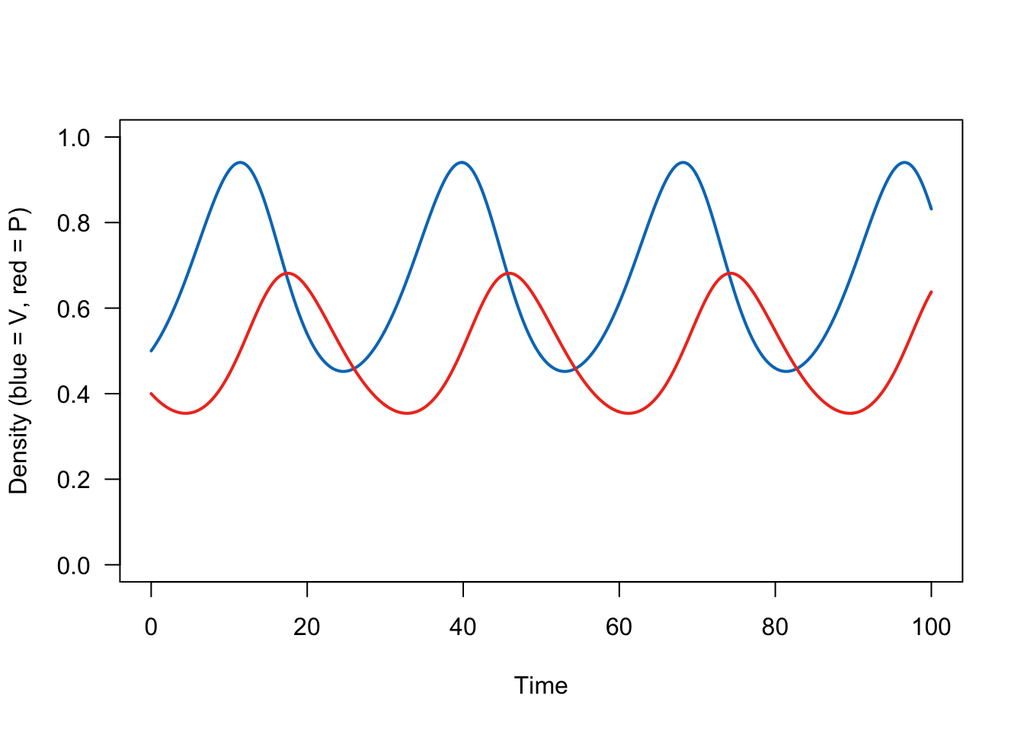

> ```r
> # Using the numerical solution from above
>   plot(x = NA, type = "n", las = 1, xlab = "Time", ylab = "Density (blue = V, red = P)", xlim = c(0, max(time_vec)), ylim = c(0, 1))
>   lines(x = out[, "time"], y = out[, "V"], lwd = 2, col = "#007ac1")
>   lines(x = out[, "time"], y = out[, "P"], lwd = 2, col = "#ef3b24")
> ```

> 1.4. In 1.2. we see the starting point as a dot with prey at a density of 0.5 and predators at 0.4. The trajectory of populations are cycles *that return to the same point* over and over. So, even though the trajectory looks ovoid, it’s just a a cycle returning to the same point. We see this, clearly, in the time series in 1.3.

## 2. Lotka-Volterra phase planes with isoclines and trajectory, part dos

Now that you have plotted the isoclines and a trajectory, I want to show you a more general way of visualizing how populations are going to change, instead of just showing a single trajectory.

But I first want to re-introduce a phrase that we taught in ecology where we had the populations (stat variables) on the horizontal and vertical axes and we plotted the isoclines to show the population dynamics. We called these *phase planes*, and I am going to use that language over the next 6 weeks or so as we study two-dimensional systems.

OK, but we are going to further make these phase planes more generally interpretable by adding a (vector) field to the background. In sum, the field shows for a given set of densities of each variable (i) the direction that the populations will change to and (ii), often, the magnitude. Here is what it would looks like for the Lotka-Volterra predator-prey model:

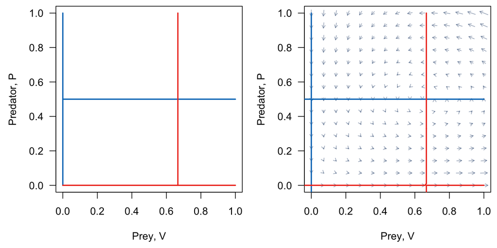

Looking at these two phase planes, it’s easy to see how much more information the vector field adds. Notice, too, that in some areas (e.g., where $V = 1$ and $P = 1$) we see arrows with long tails indicating that the rate of change is relatively high and other areas (e.g., around the positive equilibrium) the tails are so small you can’t even see them. Nevertheless, we can now qualitatively see how the populations are going to change through time—such a useful and, IMO, aesthetically-pleasing tool!

For this problem, I ask that you recreate what you did in problem 1, but using an R package that will plot both the isoclines and vector field for you 🤓. You’ll do this with a new package called `phaseR`, so you’ll need to load it from your library just like with `deSolve`. (Phaser, BTW, is a sound effect that you hear in a lot of music, including, what is one of the best openings of any music album ever, [*Shine on your crazy diamond (parts I—V)* by Pink Floyd](https://www.youtube.com/watch?v=54W8kktFE_o) [at 4:08 you can hear the guitar with phaser]).

The easiest way to make a phase plane like mine is in three steps:

1. Make a blank plot
2. Use `flowField()` to add the vector field
3. Use `nullclines()` to add the nullclines

Pretty simple, right? It is in my opinion. This package has a few things that are slightly annoying that might cause your code not to work. Here’s a list of those:

- For both `flowField()` and `nullclines()` you need to specify the `xlim` and `ylim`
- In `ode()` the argument for your function is `func =` and in `flowField()` and `nullclines()` it’s `deriv =`
- In `ode()` the argument for your parameters is `parms =` and in `flowField()` and `nullclines()` it’s `parameters =`
- You **must** give `flowField()` and `nullclines()` the names of your state variables in the `state.names =` argument; e.g., `state.names = c("Roadrunner", "Wiley E. Coyote")`
- Each `flowField()` and `nullclines()`, when plotted, returns a bunch of data that you don’t need. You can suppress the printing of the output by assigning the function to some variable. I call mine `trash` like this, for example: `trash <- flowField(...)` where the arguments are filled in where the ellipses are.

And, I always recommend that you check the documentation for each of the functions `flowField()` and `nullclines()`. You’ll find them helpful, as it tells you how to change, for instance, the size of the arrowheads, the number of points in the vector field, opting to not plot the legend, etc.

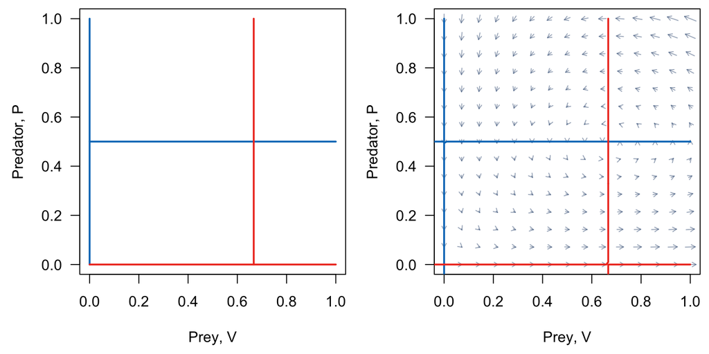

> ```r
> # ode() set up
> lv <- function(times, state, pars) {
>   with(as.list(c(state, pars)), {
>     dV <- r*V - a*V*P
>     dP <- b*V*P - m*P
>     return(list(c(dV, dP)))
>   })
> }
>
> time_vec <- seq(from = 0, to = 100, by = 0.1)
> par_vec <- c(r = 0.25, a = 0.5, b = 0.3, m = 0.2)
> init <- c(V = 0.5, P = 0.4)
>
> # Plot isoclines
>   par(mfrow = c(1, 2), mar = c(4.5, 4.5, 0.5, 0.5))
>   # Blank plot
>   plot(x = NA, type = "n", las = 1, xlab = "Prey, V", ylab = "Predator, P", xlim = c(0, 1), ylim = c(0, 1))
>
>   # Isoclines for prey
>   lines(x = c(0, 0), y = c(0,1), col = "#007ac1", lwd = 2)
>   iso_V <- par_vec["r"]/par_vec["a"]
>   lines(x = c(0, 1), y = c(iso_V, iso_V), col = "#007ac1", lwd = 2)
>
>   # Isoclines for predators
>   lines(y = c(0, 0), x = c(0,1), col = "#ef3b24", lwd = 2)
>   iso_P <- par_vec["m"]/par_vec["b"]
>   lines(y = c(0, 1), x = c(iso_P, iso_P), col = "#ef3b24", lwd = 2)
>
> # Plot isoclines + vector field
>   plot(x = NA, type = "n", las = 1, xlab = "Prey, V", ylab = "Predator, P", xlim = c(0, 1), ylim = c(0, 1))
>   trash <- flowField(deriv = lv, xlim = c(0, 1), ylim = c(0, 1), parameters = par_vec, state.names = c("V", "P"), arrow.type = "proportional", points = 15, col = "#002D6266")
>   trash <- nullclines(deriv = lv, xlim = c(-0.1, 1), ylim = c(-0.1, 1), parameters = par_vec, state.names = c("V", "P"), col = c("#007ac1", "#ef3b24"), lwd = 2, add.legend = F)
> ```